# Caballero Osorio, Fabian - Quiz 3 (Week 7) Feedback

| Course | Assessment |
| --- | --- |
| Machine Learning | Quiz 3 (Week 7) |

| Student Name | Student ID |
| --- | --- |
| Caballero Osorio, Fabian | S3912233 |

### General Assessment Feedback

This week's quiz covered data preprocessing and the nearest neighbour learner. This was a rather challenging quiz with quite a lot of content covered, yet the majority of students handled it well!

Questions 1 to 10 involved selecting which initial preprocessing method was appropriate for the given variable type, with an additional judgment on whether missing values were present. As a cohort, the majority of these were handled well with the exception of Handset_ID in which the majority of students selected to keep it as is. Although the variable itself is composed of integers, it is **not** a numerical variable, rather an integer encoding of different handsets, and therefore it is a nominal categorical variable that needs to be one-hot-encoded.

Rest of the data preprocessing questions involved obtaining specific subsets from within the dataset and it appears that as a cohort, you are comfortable subsetting Pandas data frames, which is great to see.

### Student Assessment Results & Feedback

Question

Student Answer

Correct Answer

Feedback

Score

Student Name & ID  
(link)  
(0 points)

Name: Fabian Mauricio Caballero Osorio  
Student ID: s3912233

Student Name & ID

*************************  
**STUDENT FEEDBACK:**  
*************************  
**(Student Name & ID)**

0.0

Question 1  
(link)  
(1 point)

(Q1) Customer_Code: drop it

(Q1) Customer_Code: drop it

*************************  
**STUDENT FEEDBACK:**  
*************************  
**Full credit was awarded for this answer.**  
*************************  
**GENERAL FEEDBACK:**  
*************************  
Customer code is an ID column in this case (with a unique value for each row) and needs to be dropped for predictive modeling purposes.

1.0

Question 2  
(link)  
(1 point)

(Q2) Gender: perform one-hot-encoding/ dummy encoding

(Q2) Gender: perform one-hot-encoding/ dummy encoding

*************************  
**STUDENT FEEDBACK:**  
*************************  
**Full credit was awarded for this answer.**  
*************************  
**GENERAL FEEDBACK:**  
*************************  
Gender is a binary categorical variable, and therefore dummy encoding is required.

1.0

Question 3  
(link)  
(1 point)

(Q3) Age: take action for unusual values/ outliers

(Q3) Age: take action for unusual values/ outliers

*************************  
**STUDENT FEEDBACK:**  
*************************  
**Full credit was awarded for this answer.**  
*************************  
**GENERAL FEEDBACK:**  
*************************  
Age is a numerical variable where logical bounds exist. Best practice is to take action for unusual values, especially due to the age of 223 in the dataset. Also pay attention that the Age variable has no missing values per `df['Age'].isna().sum()` returning zero.

1.0

Question 4  
(link)  
(1 point)

(Q4) Connect_Date: take action for unusual values/ outliers

(Q4) Connect_Date: drop it

*************************  
**STUDENT FEEDBACK:**  
*************************  
**No credit was awarded for this answer.**  
*************************  
**GENERAL FEEDBACK:**  
*************************  
Connect_Date is a temporal variable, so we need to drop it. Normally we would convert this date variable to a duration variable before dropping, but L_O_S (length of service) has already been calculated here for us.

0.0

Question 5  
(link)  
(1 point)

(Q5) L_O_S: take action for unusual values/ outliers

(Q5) L_O_S: keep as it is

*************************  
**STUDENT FEEDBACK:**  
*************************  
**This answer was also accepted.**  
*************************  
**GENERAL FEEDBACK:**  
*************************  
L_O_S is a numerical variable with a reasonable large upper bound, so we may keep as it is. Check for unusual values/ outliers was also accepted.

1.0

Question 6  
(link)  
(1 point)

(Q6) Pay_Method: perform one-hot-encoding/ dummy encoding

(Q6) Pay_Method: drop it

*************************  
**STUDENT FEEDBACK:**  
*************************  
**No credit was awarded for this answer.**  
*************************  
**GENERAL FEEDBACK:**  
*************************  
Pay_Method is a constant variable, that is all values are the same, so it needs to be dropped.

0.0

Question 7  
(link)  
(1 point)

(Q7) Tariff: take action for missing values

(Q7) Tariff: take action for missing values

*************************  
**STUDENT FEEDBACK:**  
*************************  
**Full credit was awarded for this answer.**  
*************************  
**GENERAL FEEDBACK:**  
*************************  
Tariff obviously has missing values, so we take action for missing values.

1.0

Question 8  
(link)  
(1 point)

(Q8) Churn: perform one-hot-encoding/ dummy encoding

(Q8) Churn: perform one-hot-encoding/ dummy encoding

*************************  
**STUDENT FEEDBACK:**  
*************************  
**Full credit was awarded for this answer.**  
*************************  
**GENERAL FEEDBACK:**  
*************************  
Churn is a binary categorical variable, so we perform dummy encoding. That is, we convert it to a binary variable that is either 0 or 1.

1.0

Question 9  
(link)  
(1 point)

(Q9) Handset_ID: keep as it is

(Q9) Handset_ID: perform one-hot-encoding/ dummy encoding

*************************  
**STUDENT FEEDBACK:**  
*************************  
**No credit was awarded for this answer.**  
*************************  
**GENERAL FEEDBACK:**  
*************************  
Handset_ID is a nominal categorical variable that is encoded as an integer, and therefore we perform one-hot-encoding.

0.0

Question 10  
(link)  
(1 point)

(Q10) Dropped_Calls: keep as it is

(Q10) Dropped_Calls: keep as it is

*************************  
**STUDENT FEEDBACK:**  
*************************  
**Full credit was awarded for this answer.**  
*************************  
**GENERAL FEEDBACK:**  
*************************  
Dropped calls is a numerical variable and more importantly the target variable. So it should be kept as it is. Check for unusual values was also accepted.

1.0

Question 11  
(link)  
(2 points)

```
### ADD YOUR CODE BELOW

a = df[df['Tariff']=='Play100'].shape
a = a[0]
b = df.shape
b = b[0]
percentage = a/b*100

### ADD YOUR CODE ABOVE

print(f"{percentage:.2f}% of callers have the Play100 Tariff")

OUTPUT:
31.35% of callers have the Play100 Tariff
```

```
### ADD YOUR CODE BELOW


# subset for Play100 Tariff
tariff = df[df['Tariff'] == "Play100"]

# Calculate the percentage
percentage = (tariff.shape[0]/ df.shape[0])*100

# percentage = 999

### ADD YOUR CODE ABOVE

print(f"{percentage:.2f}% of callers have the Play100 Tariff")

OUTPUT:
31.35% of callers have the Play100 Tariff
```

*************************  
**STUDENT FEEDBACK:**  
*************************  
**Full credit was awarded for this answer.**  
*************************  
**GENERAL FEEDBACK:**  
*************************  
The vast majority of students answered this correctly. Common mistakes included forgetting to multiply by 100 for percentages and removing NA values from the calculation.

2.0

Question 12  
(link)  
(3 points)

```
### ADD YOUR CODE BELOW
b = df[df['Gender']=='M']
b = b[b['Churn']=='Active']
male_m = b['L_O_S'].mean()

a = df[df['Gender']=='F']
a = a[a['Churn']=='Active']
a = a[a['L_O_S'] > male_m].shape

d = df[df['Gender']=='F']
d = d[d['Churn']=='Active'].shape

percentage = a[0]/d[0]*100

### ADD YOUR CODE ABOVE

print(f"{percentage:.2f}% of female callers who have churned have a greater L_O_S than the average male active caller")

OUTPUT:
40.35% of female callers who have churned have a greater L_O_S than the average male active caller
```

```
### ADD YOUR CODE BELOW

# subset for churned and female
churned = df[(df['Churn'] == "Churned")&(df['Gender'] == 'F')]

# average male active caller LOS
mean_active_male_LOS = df[(df['Gender'] == 'M') & (df['Churn'] == 'Active')]['L_O_S'].mean()

# subset for los less than average for churned and female
subset = churned[churned['L_O_S'] > mean_active_male_LOS]

# Calculate the percentage
percentage = (subset.shape[0]/ churned.shape[0])*100

# percentage = 999

### ADD YOUR CODE ABOVE

print(f"{percentage:.2f}% of female callers who have churned have a greater L_O_S than the average male active caller")

OUTPUT:
44.67% of female callers who have churned have a greater L_O_S than the average male active caller
```

*************************  
**STUDENT FEEDBACK:**  
*************************  
**No credit was awarded for this answer.**  
*************************  
**GENERAL FEEDBACK:**  
*************************  
The majority of students who attempted this question got it correct. Common mistakes included not including the active subset when calculating the L_O_S of the average male active caller and using the number of female callers rather than the number of female callers who churned as the denominator during the calculation.

0.0

Question 13  
(link)  
(4 points)

```
### ADD YOUR CODE BELOW
subset = df.groupby(['Handset_ID'],group_keys=True,as_index=False).mean(numeric_only=True).apply(lambda x:x)

i = subset['L_O_S'].idxmin(axis=0)

shortest_mean_service_time = subset['L_O_S'][i]
shortest_mean_service_handsetid = subset['Handset_ID'][i]

### ADD YOUR CODE ABOVE

print(f"{shortest_mean_service_time:.2f} months for the Handset ID {shortest_mean_service_handsetid}")

OUTPUT:
39.19 months for the Handset ID 9
```

```
### ADD YOUR CODE BELOW

shortest_mean_service_time = min(df.groupby(['Handset_ID']).mean(numeric_only=True)['L_O_S'])

shortest_mean_service_handsetid = df.groupby(['Handset_ID']).mean(numeric_only=True)['L_O_S'].idxmin()

# shortest_mean_service_time = 999
# shortest_mean_service_handsetid = 999

### ADD YOUR CODE ABOVE

print(f"{shortest_mean_service_time:.2f} months for the Handset ID {shortest_mean_service_handsetid}")

OUTPUT:
39.19 months for the Handset ID 9
```

*************************  
**STUDENT FEEDBACK:**  
*************************  
**Full credit was awarded for this answer.**  
*************************  
**GENERAL FEEDBACK:**  
*************************  
This question was answered correctly by most students who attempted it. Some students chose to manually calculate the mean times rather than using the groupby() function.

4.0

Question 14, Part A  
(link)  
(2 points)

The number of nearest neighbours considered during classification

The number of nearest neighbours considered during classification

*************************  
**STUDENT FEEDBACK:**  
*************************  
**Full credit was awarded for this answer.**  
*************************  
**GENERAL FEEDBACK:**  
*************************  
The parameter k in KNN specifies the number of nearest neighbours considered during classification.

2.0

Question 14, Part B  
(link)  
(2 points)

It can be sensitive to irrelevant features in the dataset

All of the above

*************************  
**STUDENT FEEDBACK:**  
*************************  
**No credit was awarded for this answer.**  
*************************  
**GENERAL FEEDBACK:**  
*************************  
Despite being highly popular, all the listed items are downsides of KNN in general.

0.0

Question 14, Part C  
(link)  
(2 points)

All of the above

Increasing the value of k

*************************  
**STUDENT FEEDBACK:**  
*************************  
**No credit was awarded for this answer.**  
*************************  
**GENERAL FEEDBACK:**  
*************************  
Increasing the value of k tends to smoothen out the decision boundaries in KNN and consequently helps with potential overfitting issues.

0.0

Question 14, Part D  
(link)  
(2 points)

It grows linearly with the size of the dataset

It grows linearly with the size of the dataset

*************************  
**STUDENT FEEDBACK:**  
*************************  
**Full credit was awarded for this answer.**  
*************************  
**GENERAL FEEDBACK:**  
*************************  
As we keep adding more instances to the underlying dataset, we will need to perform more distance calculations to identify the k nearest neighbours. For this reason, runtime of KNN grows linearly with the size of the dataset.

2.0

Question 15  
(link)  
(3 points)

```
import numpy as np
import pandas as pd

df = pd.read_csv("telco.csv")

feature_name =  str(input('Waiting for input: '))  # example: Age
num_bins = int(float(input('Waiting for input: '))) # example: 5


def equal_width_binning(feature_name, num_bins, df=df):

    df_0 = df['feature_name']
    # Inputs:
    # feature_name: a string of a feature name in df
    # num_bins: a positive integer greater than 1
    # df: A pandas dataframe

    # Outputs:
    # bins: a numpy array

    # Get the values of the feature
    feature = df[feature_name]

    ### ADD YOUR CODE BELOW


    bins = np.repeat(999, len(feature))

    ### ADD YOUR CODE ABOVE

    return bins


# we will print the first 10 bin membership for simplicity
print(f"{equal_width_binning(feature_name, num_bins)[0:10]}")

UNIT TEST RESULTS:
Test 1: Failed. (Test did not execute successfully)
```

```
import numpy as np
import pandas as pd

df = pd.read_csv("telco.csv")

feature_name =  str(input('Waiting for input: '))  # example: Age
num_bins = int(float(input('Waiting for input: '))) # example: 5


def equal_width_binning(feature_name, num_bins, df=df):

    # Inputs:
    # feature_name: a string of a feature name in df
    # num_bins: a positive integer greater than 1
    # df: A pandas dataframe

    # Outputs:
    # bins: a numpy array

    # Get the values of the feature
    feature = df[feature_name]

    ### ADD YOUR CODE BELOW


    # Get the range of the feature
    feature_min = min(feature)
    feature_max = max(feature)

    # Calculate equal bin widths
    bin_ranges = np.linspace(feature_min, feature_max, num_bins+1)

    # Initialise a numpy array to the largest bin (don't need a seperate condition for the maximum entry)
    bins = np.repeat(num_bins, len(feature))

    # Assign bins
    for index in range(1, num_bins+1):
        bins[(feature >= bin_ranges[index-1]) & (feature < bin_ranges[index])] = index

    # bins = np.repeat(999, len(feature))

    ### ADD YOUR CODE ABOVE

    return bins


# we will print the first 10 bin membership for simplicity
print(f"{equal_width_binning(feature_name, num_bins)[0:10]}")
```

*************************  
**STUDENT FEEDBACK:**  
*************************  
**No credit was awarded for this answer.**  
*************************  
**GENERAL FEEDBACK:**  
*************************  
A handful of students got the challenge question correct. Well done to those who did!

0.0

TOTAL: 17.0/30

### Assessment Unit Tests

| Question | Test Name | Test Input | Required Test Output |
| --- | --- | --- | --- |
| Question 15 | Test 1 | L_O_S; 10 | [6 5 1 4 3 2 1 4 5 2] |

### Assessment Scores Histogram

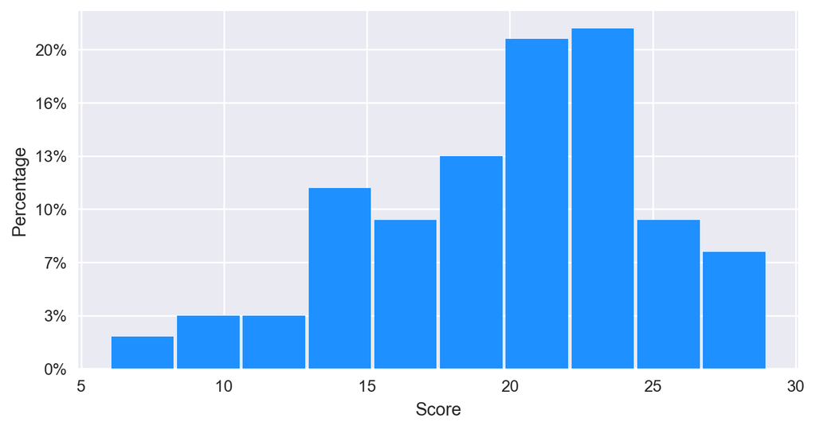

## Assessment Questions

**CODE OF CONDUCT**

- **Use of ChatGPT or similar AI tools is STRICTLY FORBIDDEN in our bi-weekly quizzes.**
- This is a "**limited open-computer**" assessment.
- **You must work on this assessment on your own and you must neither provide nor receive any help from anyone.**
- **You must not share this questions notebook nor your solutions with anyone, neither before submission nor after.**
- Please see Canvas for the full `Code of Conduct`.

**INSTRUCTIONS**

1. You **must not** delete any existing cells in this notebook and you **must not** modify any existing cell tags. If you accidentally delete a cell, you will need to go to the "Edit" menu option and select "Undo Delete Cells".
2. In an answer cell, any direct action **required from you** will be indicated by UPPER CASE PYTHON COMMENTS starting with "###".
3. In general, the value of "999" will denote a dummy placeholder.
4. You **must not change even a single character** in an existing code cell that is **outside** of the "ADD YOUR CODE BELOW/ ABOVE" block.
5. You **must not** have any additional print() statement outputs of your own for any question in your submission.
6. You **must** run each and every one of your answer cells so that your answers are recorded correctly for marking purposes.
7. Please keep in mind that, if you select "*Restart & Clear Output*" or "*Restart & Run All*" from the "*Kernel*" menu option, your answers for any multiple-choice questions will reset to "**nothing selected**".
8. Please see Canvas for additional assessment instructions.
9. This assessment has 15 questions for a total of 30 points.
10. Good luck!

```python
### PLEASE RUN THIS CELL SO THAT THE DROPDOWN ANSWER SELECTIONS BELOW WORK CORRECTLY
### WARNING!! If you restart your kernel, you will need to run this cell again.
from ipywidgets import interactive
def function_mcq(selection): pass
```

```python
### PLEASE FIRST WRITE YOUR FULL NAME AND STUDENT ID BELOW,
### AND THEN EXECUTE THIS CODE CELL.
# Thank you.
print("""
Name:
Student ID:
""")
```

### Questions 1 to 10 (1 point each)

You are presented a dataset titled `telco` representing data on customers of a telecommunications company (such as Telstra/ Optus/ Vodafone). You can find this CSV file inside the Canvas Quiz page where you downloaded this Questions notebook ("telco.csv").

**WARNING:** You **MUST** make sure that your Jupyter notebook and this CSV file are in the same folder. If you are on Google Colab, you need to upload this CSV file under the session storage at the root level. Please see the bottom of [this page](https://rmit.instructure.com/courses/106983/pages/jupyter-notebooks-on-the-cloud-google-colab) for more information.

There are 10 variables and 960 observations in this dataset. These variables and their descriptions are given below.

- `Customer_Code`: Code of the customer in the database
- `Gender`: Male or female
- `Age`: Age in years
- `Connect_Date`: Date phone service was started
- `L_O_S`: Length of Service (since phone was connected), in months
- `Pay_Method`: Method of payment
- `Tariff`: Type of tariff associated with the service
- `Churn`: Binary Flag (Churned or Active)
- `Handset_ID`: ID of Handset type
- `Dropped_Calls` (**Dependent Variable**): Number of cellular calls that were disconnected

```python
### RUN THIS CODE SO THAT YOU CAN SEE THE DATASET
import pandas as pd
df = pd.read_csv("telco.csv")
df.head(10)
```

|  | Customer_Code | Gender | Age | Connect_Date | L_O_S | Pay_Method | Tariff | Churn | Handset_ID | Dropped_Calls |
| --- | --- | --- | --- | --- | --- | --- | --- | --- | --- | --- |
| 0 | K114900 | F | 21 | 23/8/2019 | 92.0 | Prepaid | CAT100 | Active | 9 | 0 |
| 1 | K131970 | F | 223 | 27/5/2018 | 68.0 | Prepaid | CAT50 | Active | 7 | 6 |
| 2 | K183900 | M | 42 | 16/1/2020 | 3.1 | Prepaid | CAT50 | Active | 3 | 1 |
| 3 | K124650 | F | 16 | 27/9/2018 | 56.0 | Prepaid | NaN | Churned | 5 | 5 |
| 4 | K196120 | M | 52 | 21/12/2020 | 39.9 | Prepaid | Play100 | Active | 7 | 1 |
| 5 | K167220 | M | 24 | 12/10/2017 | 23.0 | Prepaid | CAT100 | Active | 2 | 4 |
| 6 | K186150 | F | 43 | 4/4/2017 | 15.4 | Prepaid | Play100 | Churned | 5 | 1 |
| 7 | K175060 | F | 27 | 4/11/2019 | 58.3 | Prepaid | CAT100 | Active | 9 | 5 |
| 8 | K174550 | M | 31 | 6/8/2017 | 81.2 | Prepaid | CAT50 | Active | 8 | 4 |
| 9 | K192940 | M | 50 | 21/6/2018 | 24.7 | Prepaid | CAT50 | Active | 8 | 2 |

Your goal is to build a model for prediction of the `Dropped_Calls` numerical variable. Based on this dataset, describe the **first** data pre-processing step that needs to be taken, if any, for each one of the 10 variables prior to this predictive modeling. Your answers should be based on our data preprocessing course materials.

**NOTE 1**: Your answers **MUST** be based on this particular dataset and not some generic recommendations.

**NOTE 2**: You will obviously need to limit your answers to the available options in the multiple-choice questions below. For instance data scaling will not appear among the choices for simplicity.

**NOTE 3**: You do **NOT** need to perform any of the steps you selected. In fact, You **MUST NOT** change this dataset in any way throughout this entire assessment.

```python
### PLEASE RUN THIS CELL
### AND THEN MAKE YOUR SELECTIONS BELOW

df_columns = df.columns.tolist()

selection_list=['nothing selected',
           'keep as it is',
           'drop it',
           'take action for missing values',
           'take action for unusual values/ outliers',
           'perform one-hot-encoding/ dummy encoding  ',]

answer_dict = dict()

for qn_no, column in enumerate(df_columns, start=1):
    column_selection = ['(Q' + str(qn_no) + ') ' + column + ': ' + selection for selection in selection_list]
    ans = interactive(function_mcq, selection = column_selection);
    answer_dict[column] = ans
    display(ans)
```

```python
### PLEASE RUN THIS CELL AFTER YOUR SELECTION ABOVE
print(f"{answer_dict['Customer_Code'].kwargs['selection']}")
```

```python
### PLEASE RUN THIS CELL AFTER YOUR SELECTION ABOVE
print(f"{answer_dict['Gender'].kwargs['selection']}")
```

```python
### PLEASE RUN THIS CELL AFTER YOUR SELECTION ABOVE
print(f"{answer_dict['Age'].kwargs['selection']}")
```

```python
### PLEASE RUN THIS CELL AFTER YOUR SELECTION ABOVE
print(f"{answer_dict['Connect_Date'].kwargs['selection']}")
```

```python
### PLEASE RUN THIS CELL AFTER YOUR SELECTION ABOVE
print(f"{answer_dict['L_O_S'].kwargs['selection']}")
```

```python
### PLEASE RUN THIS CELL AFTER YOUR SELECTION ABOVE
print(f"{answer_dict['Pay_Method'].kwargs['selection']}")
```

```python
### PLEASE RUN THIS CELL AFTER YOUR SELECTION ABOVE
print(f"{answer_dict['Tariff'].kwargs['selection']}")
```

```python
### PLEASE RUN THIS CELL AFTER YOUR SELECTION ABOVE
print(f"{answer_dict['Churn'].kwargs['selection']}")
```

```python
### PLEASE RUN THIS CELL AFTER YOUR SELECTION ABOVE
print(f"{answer_dict['Handset_ID'].kwargs['selection']}")
```

```python
### PLEASE RUN THIS CELL AFTER YOUR SELECTION ABOVE
print(f"{answer_dict['Dropped_Calls'].kwargs['selection']}")
```

**Go to Top**

### Question 11 (2 points)

What percentage of callers have the `Play100` Tariff?

```python
### ADD YOUR CODE BELOW


percentage = 999

### ADD YOUR CODE ABOVE

print(f"{percentage:.2f}% of callers have the Play100 Tariff")
```

**Go to Top**

### Question 12 (3 points)

What percentage of female callers who have churned have a greater `L_O_S` than the average male active caller?

```python
### ADD YOUR CODE BELOW


percentage = 999

### ADD YOUR CODE ABOVE

print(f"{percentage:.2f}% of female callers who have churned have a greater L_O_S than the average male active caller")
```

**Go to Top**

### Question 13 (4 points)

Across all the different Handset types, what is the shortest average service time in this dataset (in months)? That is, find the average `L_O_S` time across the Handsets and report the smallest of them. You will also report the ID of the corresponding Handset.

**Hint:** You can use the `groupby()` and `idxmin()` functions.

**WARNING:** If you are working with Pandas version 2.0 or above, you will need to pass in the parameter value `numeric_only=True` to the mean() function for this question, otherwise it will **not** work. So, your code will include the following:

```
df.groupby(['Handset_ID']).mean(numeric_only=True)
```

```python
### ADD YOUR CODE BELOW


shortest_mean_service_time = 999
shortest_mean_service_handsetid = 999

### ADD YOUR CODE ABOVE

print(f"{shortest_mean_service_time:.2f} months for the Handset ID {shortest_mean_service_handsetid}")
```

**Go to Top**

### Question 14 (8 points, 2 points per part)

**PART (A):** In the nearest neighbor algorithm, what does the parameter k determine?

```python
### PLEASE RUN THIS CELL
q14a = interactive(function_mcq,
                 selection=['nothing selected',
                            'The number of features in the dataset ',
                            'The number of clusters in the dataset ',
                            'The number of nearest neighbours considered during classification ',
                            'The number of observations in the dataset ']);
display(q14a)
```

```python
### PLEASE RUN THIS CELL AFTER YOUR SELECTION ABOVE
print(f"{q14a.kwargs['selection']}")
```

**PART (B):** Which of the following is a disadvantage of the nearest neighbor algorithm?

**NOTE:** Please pay attention that the choice of "nothing selected" means just that in our quizzes and it is not included in the "All of the above" choices.

```python
### PLEASE RUN THIS CELL
q14b = interactive(function_mcq,
                 selection=['nothing selected',
                            'It requires a lot of space to store the entire dataset ',
                            'It can be sensitive to irrelevant features in the dataset ',
                            'It is not suitable for high-dimensional data ',
                            'All of the above']);
display(q14b)
```

```python
### PLEASE RUN THIS CELL AFTER YOUR SELECTION ABOVE
print(f"{q14b.kwargs['selection']}")
```

**PART (C):** Which of the following is a common approach to avoid overfitting in the nearest neighbor algorithm?

```python
### PLEASE RUN THIS CELL
q14c = interactive(function_mcq,
                 selection=['nothing selected',
                            'Increasing the value of k ',
                            'Decreasing the value of k ',
                            'Using a more complex distance metric ',
                            'All of the above']);
display(q14c)
```

```python
### PLEASE RUN THIS CELL AFTER YOUR SELECTION ABOVE
print(f"{q14c.kwargs['selection']}")
```

**PART (D):** Which of the following is true about the running time of the nearest neighbor algorithm?

```python
### PLEASE RUN THIS CELL
q14d = interactive(function_mcq,
                 selection=['nothing selected',
                            'It is independent of the size of the dataset ',
                            'It grows linearly with the size of the dataset ',
                            'It grows exponentially with the size of the dataset ',
                            'It is impossible to deduce running time of the algorithm']);
display(q14d)
```

```python
### PLEASE RUN THIS CELL AFTER YOUR SELECTION ABOVE
print(f"{q14d.kwargs['selection']}")
```

**Go to Top**

### Question 15: Challenge Question (3 points)

**This is a Challenge Question, please only attempt this AFTER attempting the rest of the questions!**

**Also be aware of how much time you have left!**

Write a function which performs equal width binning for a numerical variable within the `telco` dataset. It takes a numerical feature name, number of bins, and the Pandas dataset name as inputs; and returns a Numpy array corresponding to the mapping of rows to bin number for that feature.

Please set the name of bins as integers starting at 1 in ascending order and note that number of bins must be 2 or greater.

With the exception of the bin with the largest values, the bins should contain the values of it's lower limits but not those which are exactly equal to the upper limits.

**Note:** You do **not** need to check for validity of the function inputs.

**Hint:** You can use `np.linspace()` for this question.

**WARNING:** You may **not** use Pandas' `cut()` function for this question. That is, your code **MUST NOT** contain the string "cut".

```python
import numpy as np
import pandas as pd

df = pd.read_csv("telco.csv")

feature_name =  str(input('Waiting for input: '))  # example: Age
num_bins = int(float(input('Waiting for input: '))) # example: 5


def equal_width_binning(feature_name, num_bins, df=df):

    # Inputs:
    # feature_name: a string of a feature name in df
    # num_bins: a positive integer greater than 1
    # df: A pandas dataframe

    # Outputs:
    # bins: a numpy array

    # Get the values of the feature
    feature = df[feature_name]

    ### ADD YOUR CODE BELOW


    bins = np.repeat(999, len(feature))

    ### ADD YOUR CODE ABOVE

    return bins


# we will print the first 10 bin membership for simplicity
print(f"{equal_width_binning(feature_name, num_bins)[0:10]}")
```

**Go to Top**

Marking & Feedback by **[SageGrader.com](https://sagegrader.com)**: The Sage Way To Grade.